# A quick RMarkdown tutorial

## From the introduction earlier

I had a few graphs in the introduction earlier:

### Scalability

Processing times for perfectly (or “embarassingly”) parallelizable problems scale linearly:

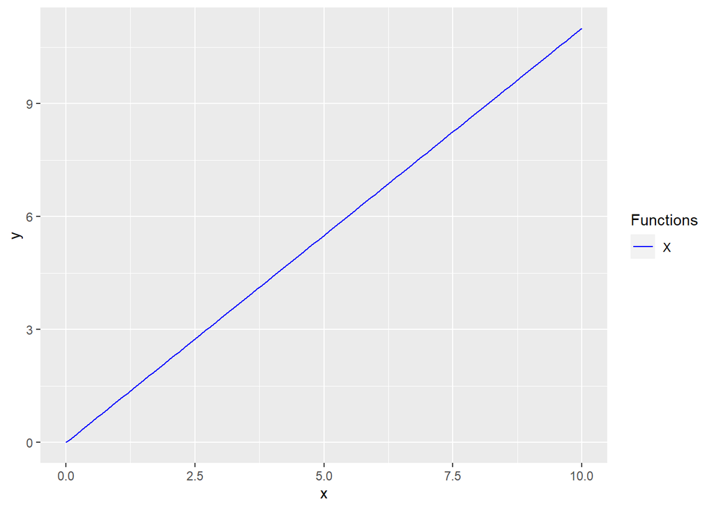

However, some problems scale quadratically:

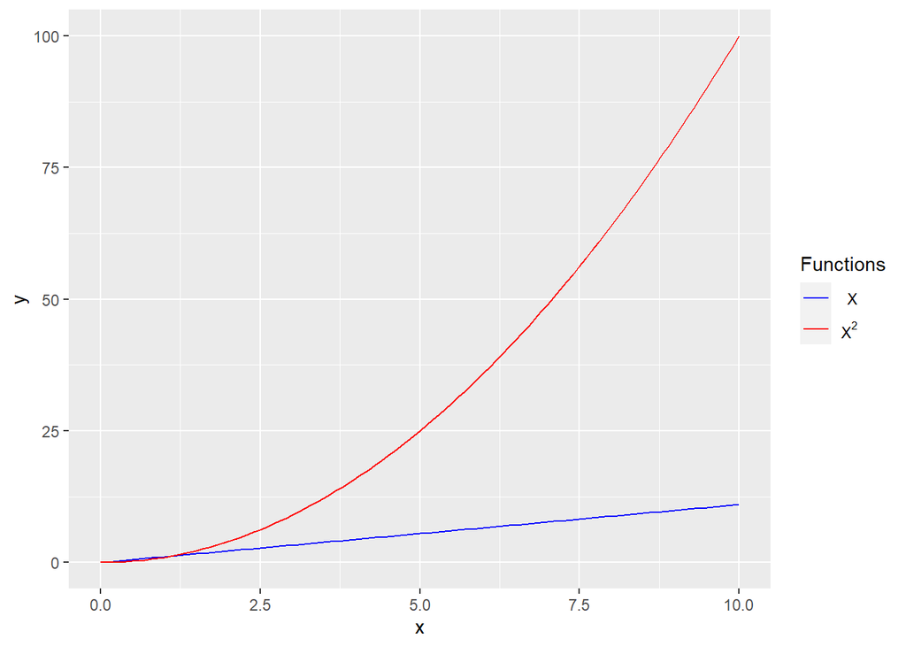

So the trick is to find solutions that scale with less than quadratic increases, such as $X\sqrt(X)$:

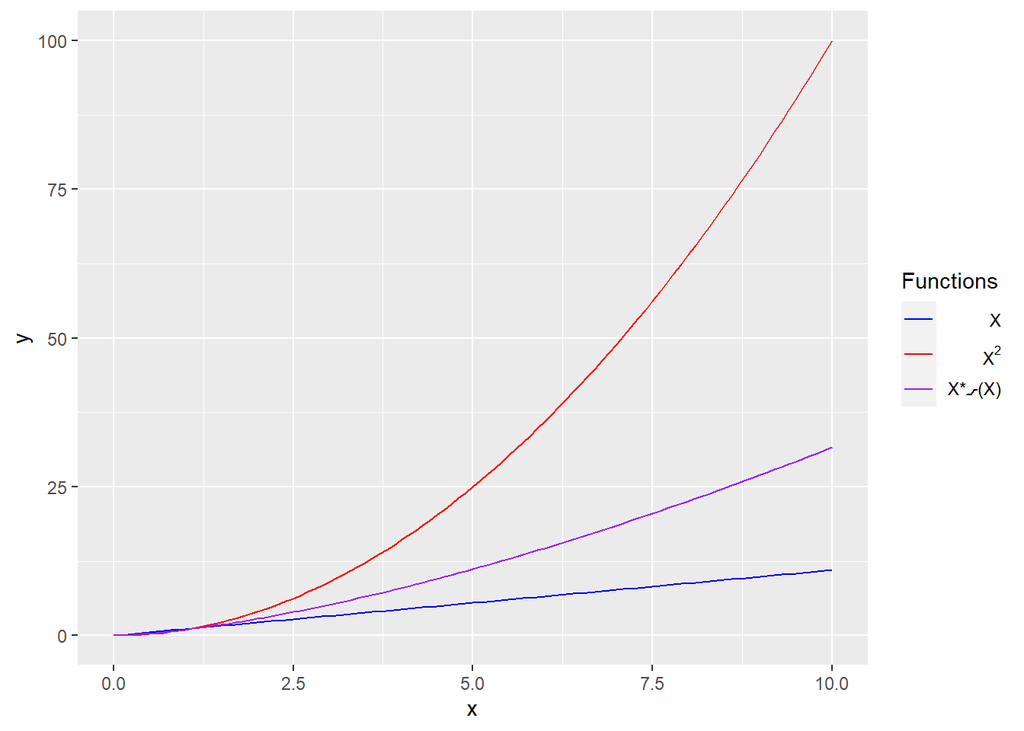

The reason is obvious when you let this run for large numbers (precisely where this becomes salient):

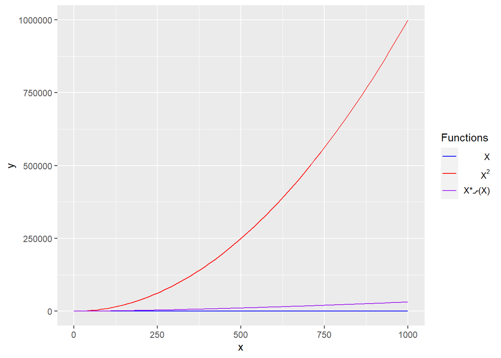

## End of example

- So why use this in general?
- And what if I won’t be using R because … ?

## Using Rmarkdown with Stata

- An example
- Key element: defining the Stata “engine”

```
stataexe <- "C:/Program Files/Stata16/StataSE-64.exe"
knitr::opts_chunk$set(engine.path=list(stata=stataexe))
```

```r
stataexe <- "C:/Program Files/Stata16/StataSE-64.exe"
knitr::opts_chunk$set(engine.path=list(stata=stataexe))
```

and then marking code chunks as executable by Stata:

````
```{stata, collectcode=TRUE}
sysuse auto
summarize
```
````

which runs Stata in the background as

```
running: C:/Program Files/Stata16/StataSE-64.exe  /q /e do
"C:\path\to\code\stata4c7c7b5a7791.do"
```

which then yields in the text:

```stata
sysuse auto
summarize
```

```
##
##
## . sysuse a(1978 Automobile Data)
##
## . summarize
##
##     Variable |        Obs        Mean    Std. Dev.       Min        Max
## -------------+---------------------------------------------------------
##         make |          0
##        price |         74    6165.257    2949.496       3291      15906
##          mpg |         74     21.2973    5.785503         12         41
##        rep78 |         69    3.405797    .9899323          1          5
##     headroom |         74    2.993243    .8459948        1.5          5
## -------------+---------------------------------------------------------
##        trunk |         74    13.75676    4.277404          5         23
##       weight |         74    3019.459    777.1936       1760       4840
##       length |         74    187.9324    22.26634        142        233
##         turn |         74    39.64865    4.399354         31         51
## displacement |         74    197.2973    91.83722         79        425
## -------------+---------------------------------------------------------
##   gear_ratio |         74    3.014865    .4562871       2.19       3.89
##      foreign |         74    .2972973    .4601885          0          1
```

- more details, see [StataMarkdown tutorial](https://www.ssc.wisc.edu/~hemken/Stataworkshops/Stata%20and%20R%20Markdown/StataMarkdown.html) (local version)

## The use of “engines”

Engines (or kernels, in Jupyter notation) are at the core of dynamic documents. They define how you can run things. Thus, if you can define a way to run a piece of software programmatically - from the command line! - you can run it from some dynamic document.

## That command line again

A recurring feature of many of these tools are the ability to run code from the command line.

- notice that we did not use the GUI to Stata!
- the command line would have been different on MacOS or on Linux
- the Linux version would have worked on BioHPC as well!

## When should you use Dynamic Documents?

- Should you write your next term paper or article in Rmarkdown?
- Should you write your instructions on how to run code in Rmarkdown?
- Should you inline all code, or write code externally?

What does that last piece mean? Inline code is written directly into the Rmarkdown, and has to be run (mostly) by running the Rmd file:

````
  ```{r pressure, echo=FALSE}
  plot(pressure)
  ```
````

Externalizing the code into a file would mean

````
  ```{r pressure, echo=FALSE}
  source("pressure.R", echo =TRUE)
  ```
````

What’s the difference?

You can execute `pressure.R`

- by calling R directly (`Rscript pressure.R`)
- by calling it from the Rmd file (see above)
- by calling it from Stata! (using an external call to R)
- or any other combination